# Coursework Report

*N* removed NAs: 4

*N* removed <18: 28

*N* total clean: 136

| Group | *N* | *M*<sub>age</sub> | % green |
| --- | --- | --- | --- |
| Control | 67 | 21.2 | 48.3 |
| Experim | 69 | 21.6 | 36.7 |

| Gender | *N* | *M*<sub>age</sub> | % green |
| --- | --- | --- | --- |
| Male | 66 | 21.3 | 46.0 |
| Female | 46 | 21.1 | 40.6 |
| Other | 24 | 22.0 | 36.1 |

**Main analysis results**

**car:**  
χ<sup>2</sup>(1) = 0.1, *p* = .753

**cleaner:**  
χ<sup>2</sup>(1) = 4.95, *p* = .026

**dishwasher:**  
χ<sup>2</sup>(1) = 1.03, *p* = .310

# Coursework Report

Analysing Data, Spring 2020

# Methods

## Participants

Table 1 *Participant Demographics by Experimental Condition*

[output not shown]

## Design

This is a replication attempt of the study conducted by Griskevicius, Tybur, and Van den Bergh (2010). We researched whether there was an association between buying greener, more environmentally-friendly products and status motives. The study used a between-subjects design composed of two experimental conditions, either status or control. This was distinguished by participants who were assigned to the status condition, read a story which aimed at eliciting high-status principles (by focusing on luxurier items in the office that was being described). Participants in the control condition read a neutral story which did not actively prime for high-status motive activation. The independent variable was the story condition, this was a factor combined of two levels, high-status or control, as described above. The dependent variable was the product selection, which is a factor consisting of two levels, a luxury non-green item or a green, more environmentally-friendly item. There were 3 categories of products: a car, a cleaner and a dishwasher. The participants choice of item was recorded, and this highlights whether product selection can be influenced by status priming. It was predicted that people who read the high-status story will choose the greener item, instead of the luxury product, more frequently than those who read the control story. A chi-square test of independence was used to determine whether story condition is associated with the product selection.

# Results

Table 2 *Observed Proportion of Product Choice by Story Condition*

|  | control | experimental |
| --- | --- | --- |
| luxury | 52 | 63 |
| green | 48 | 37 |

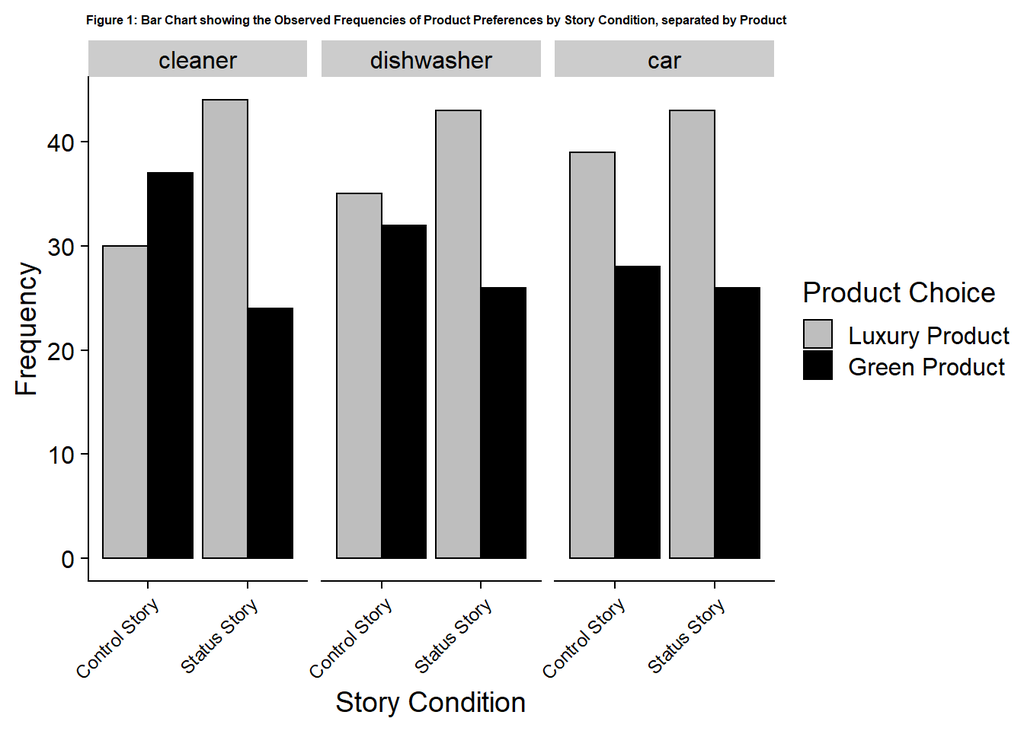

In both conditions, the luxury car was chosen more than the green car, as seen in Table 3, 62% of the participants chose the luxury car, and a similar 58% in the control condition that selected the same item, *χ*<sup>2</sup>(1) = 0.1, *p* = 0.753.

Table 3 *Observed Proportion of Car Preference by Story Condition*

|  | control | experimental |
| --- | --- | --- |
| luxury | 58 | 62 |
| green | 42 | 38 |

A similar difference was found in the dishwasher choice, and again the luxury alternative was more popular, Table 4 shows this. Again, 62% of participants in the high-status condition chose the luxury dishwasher instead of the green dishwasher, and 52% of participants in the control condition selecting the luxury dishwasher, *X*<sup>2</sup>(1) = 1.03, *p* = 0.31.

Table 4 *Observed Proportion of Dishwasher Preference by Story Condition*

|  | control | experimental |
| --- | --- | --- |
| luxury | 52 | 62 |
| green | 48 | 38 |

*Table 5* Observed Proportion of Cleaner Preference by Story Condition*

|  | control | experimental |
| --- | --- | --- |
| luxury | 45 | 65 |
| green | 55 | 35 |

# Discussion

Overall, existing evidence does suggest that there is an association between green consumption and high social status, which is not consistent with our results. For example, previous research by Dagher and Itani (2014) found a significant association between the purchasing of green products and the promotion of their self-image. This was further replicated by both Lee (2008) and Nyborg et al. (2006) who similarly found that self-image is improved by purchasing environmentally friendly products. This can be ascribed to the consumer wanting to appear environmentally concerned, thus projecting a positive image of themselves and boosting their status, this provides empirical support for the original study by Griskevicius, Tybur, and Van den Bergh (2010). Contrary to the previous findings, these results were not replicated in our study, we did not find that conspicuous consumption of green products reflected higher status. Similar to our results, Berger (2017) found that high-status was more frequently associated with the luxury item instead of the greener item. These inconsistencies could be attributed to the costly signally theory of altruism as described by Blige Bird and Smith (2005), which demonstrates that only purchasing an expensive green product is associated with altruistic signals of high-status and not just a regular price green product. This then leads to an explanation for a design limitation that could have eliminated the association between high-status and green consumerism in our study.

As such, our study did not manipulate or display the costs of the 3 product choices, which could have influenced the participants decisions. One possible explanation is that luxury, designer items are typically costly to the consumer, and so without knowledge of the prices, participants may have used their everyday consumer knowledge to assume that the luxury item was pricey and thus seen as a costly signal of high-status and wealth. Building on from this, green items are often seen as inaccessible for all consumers due to price/availability. Without assessing the participants perceived social status, we cannot assume all participants prior accessibility to green consumerism, and so they may perceive these items as unachievable and this could account for the green product being less frequently chosen in our study. Additionally, the participants in our study were particularly young (*Range*<sub>age</sub> = 18 - 28), this demographic could have severely limited our findings, for example, Gordon-Wilson (2015) demonstrated that older consumers actively purchase more greener products than younger consumers, perhaps due to greater disposable income as green products are typically costly to the consumer. As such this could provide explanation for why the findings of Griskevicius, Tybur, and Van den Bergh (2010) was not replicated in our experiment.

Based on this, further research could study the attitudes of people after buying green products, this is crucial in identifying the relationship between conspicuous consumption and the purchasing of green products. This could potentially explore the interplaying nature between an individual motive to signal high-status, green consumerism and attitudes towards the environment. This could be achieved by using a combination of qualitative and quantitative methods to discover covert reasoning for purchasing the green products. A post-experimental semi-structured interview (like the interview method used by Kennedy and Horne (2019) designed to discover covert attitudes for green consumerism) could be key in the profiling of the typical green consumer. This could have influential implications in the marketing and sales of green products by understanding the needs of the typical consumer to provide suitable, attractive products. Furthermore, it would be interesting to explore other variable such as gender or age that moderate the relationship between status motives and the purchasing of green items, as outlined in Peattie (2001). This could help further understand our initial research question of why people purchase green products.

# References

Berger, J. (2017). Are Luxury Brand Labels and “Green” Labels Costly Signals of Social Status? An Extended Replication. PLOS ONE, 12(2), e0170216. https://doi.org/10.1371/journal.pone.0170216

Bliege Bird, R., & Smith, E. A. (2005). Signaling Theory, Strategic Interaction, and Symbolic Capital. Current Anthropology, 46(2), 221–248. https://doi.org/10.1086/427115

Dagher, G. K., & Itani, O. (2014). Factors influencing green purchasing behaviour: Empirical evidence from the Lebanese consumers: Lebanese consumers’ green purchasing behaviour. Journal of Consumer Behaviour, 13(3), 188–195. https://doi.org/10.1002/cb.1482

Griskevicius, V., Tybur, J. M., & Van den Bergh, B. (2010). Going green to be seen: Status, reputation, and conspicuous conservation. Journal of Personality and Social Psychology, 98(3), 392–404. https://doi.org/10.1037/a0017346

Kennedy, E. H., & Horne, C. (2019). Do Green Behaviors Earn Social Status?: Socius. https://doi.org/10.1177/2378023119836330

Lee, K. (2008). Opportunities for green marketing: Young consumers. Marketing Intelligence & Planning, 26(6), 573–586. https://doi.org/10.1108/02634500810902839

Nyborg, K., Howarth, R. B., & Brekke, K. A. (2006). Green consumers and public policy: On socially contingent moral motivation. Resource and Energy Economics, 28(4), 351–366. https://doi.org/10.1016/j.reseneeco.2006.03.001

Peattie, K. (n.d.). Golden goose or wild goose? The hunt for the green consumer. Business Strategy and the Environment, 10(4), 187–199.